[OHI Science](http://ohi-science.org) | [Citation policy](http://ohi-science.org/citation-policy/)

# CRS Prep & Review

Anna Ramji

2024

Setup

Data describing commercial landings (tonnes) in 2017.

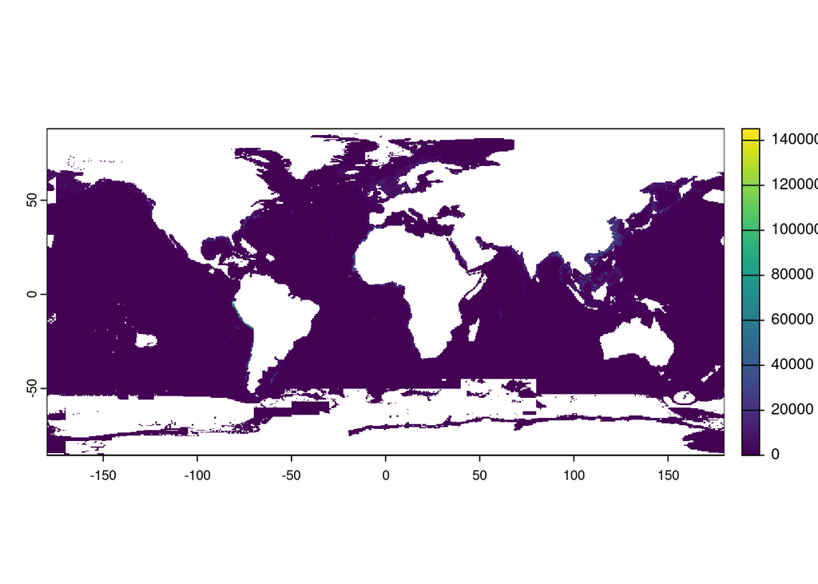

```r
# Read in commercial landings data
fish <- rast(here("Reference", "CRS", "commercial_landings_2017.tif"))

## Take a look
plot(fish)
```

```r
# lets log so we can visualize this a little better
plot(log(fish+1))
```

[output not shown]

How many fish were captured?

```r
global(fish, "sum", na.rm = TRUE)
```

```
##                               sum
## commercial_landings_2017 86331119
```

```r
# 86.3 million tonnes
```

Check against Sea Around Us to make sure this seems generally reasonable.

- seems a little low https://www.seaaroundus.org/data/#/global?chart=catch-chart&dimension=sector&measure=tonnage&limit=10 but generally makes sense (close enough)
- around 100 million https://www.seaaroundus.org/data/#/global?chart=catch-chart&dimension=sector&measure=tonnage&limit=10

What is the area of each cell?

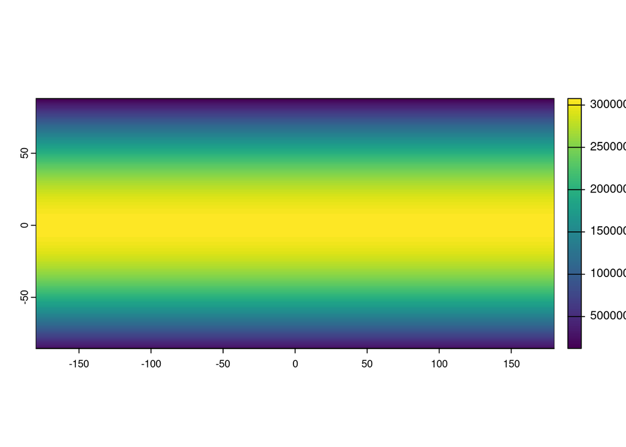

```r
cell_area <- cellSize(fish)
plot(cell_area, box = TRUE)
```

Describe what the plotted image is saying?

- cell size is much smaller at the poles, increases as you head in towards the equator

Given this, what is kind of deceptive about these plots?

- if density of fish landings in tonnes, pole values would appear higher than they are – apparent tonnes per cell would be higher
- if count, same thing (seems higher than in reality)

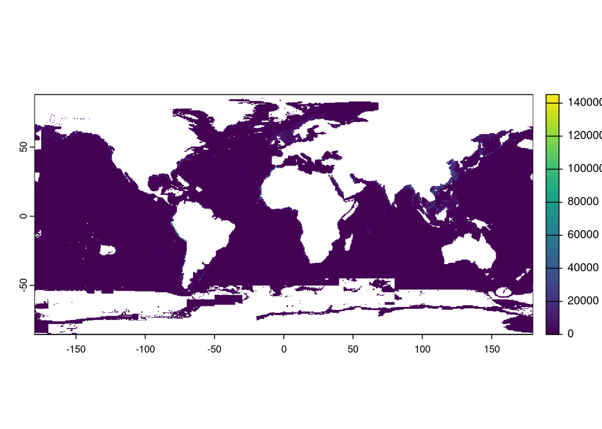

```r
plot(fish)
```

```r
# lets log so we can visualize this a little better
plot(log(fish+1))
```

[output not shown]

- the cells in the northern and southern extremes have a much smaller area than those concentrated in the center
- this may hide higher commercial fishing values in the center band, as those pixels will appear smaller when plotted
- value associated w the cell is changing when you convert – resampling by diff method (nearest neighbor, linear interpolation, bilinear)
- poles may appear to have higher values than they actually do – same value over smaller area = higher density value
- more coarse resolution at the poles can lead to higher catch shown over a greater area than in reality
- when we sum values across cells, the area of that cell is relevant when we do a global summation:
  - From the documentation on `cellSize()`

> Compute the area covered by individual raster cells. Computing the surface area of raster cells is especially relevant for longitude/latitude rasters.

> But note that for both angular (longitude/latitude) and for planar (projected) coordinate reference systems raster cells sizes are generally not constant, unless you are using an equal-area coordinate reference system.

> For planar CRSs, the area is therefore not computed based on the linear units of the coordinate reference system, but on the *actual* area by transforming cells to longitude/latitude. If you do not want that correction, you can use transform=FALSE or init(x, prod(res(x)))

Let’s convert these data to another coordinate reference system:

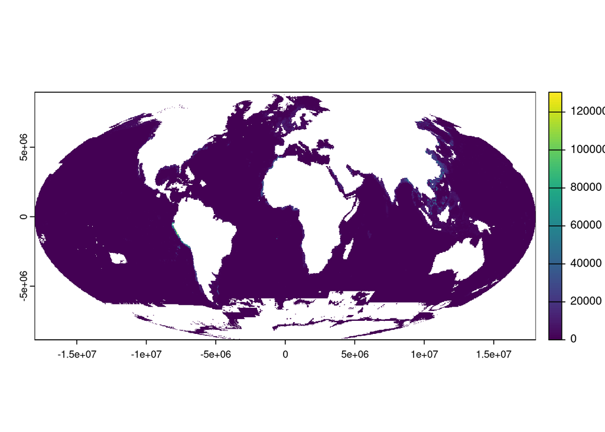

```r
moll <- "+proj=moll +lon_0=0 +x_0=0 +y_0=0 +datum=WGS84 +units=m +no_defs"
fish_moll <- terra::project(fish, crs(moll))

# take a look
par(mar = c(5, 4, 4, 0)) # set margins: bottom, left, top, right
plot(fish_moll)
```

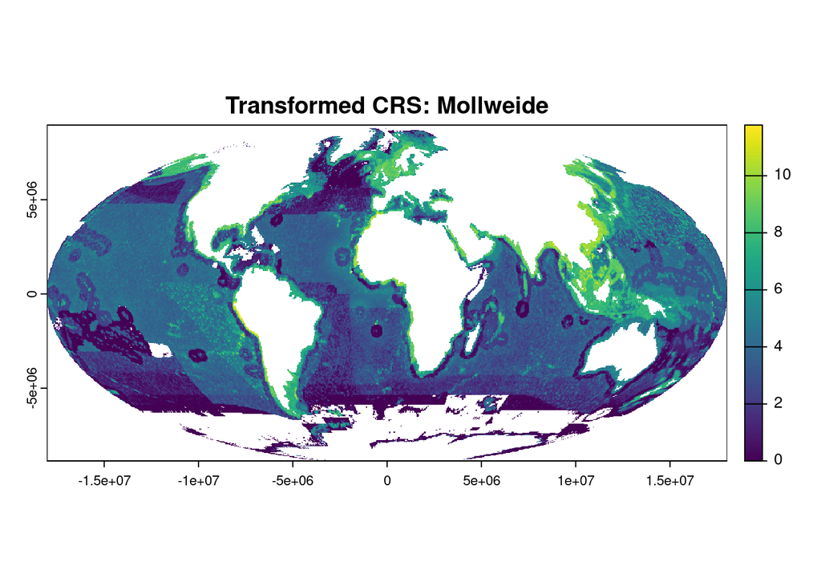

```r
plot(log(fish_moll + 1), main = "Transformed CRS: Mollweide")
```

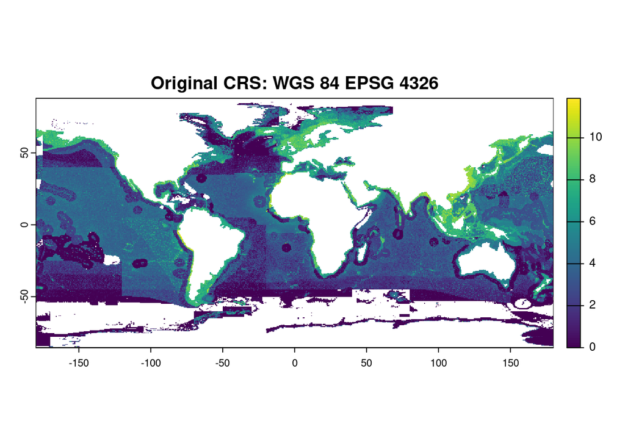

```r
plot(log(fish+1), main = "Original CRS: WGS 84 EPSG 4326")
```

```r
## Count the total tonnes
global(fish_moll, "sum", na.rm = TRUE)
```

```
##                                sum
## commercial_landings_2017 389271065
```

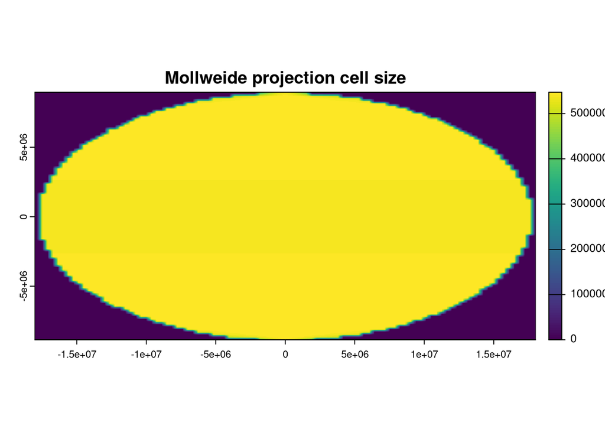

```r
# 389.3 million

# calculate cell area
cell_area_moll <- cellSize(fish_moll)

#par(mai = c(1, 1, 3, 5)) # set margins: bottom, left, top, right
#par(oma = c(1, 1, 3, 4))
#par(mar = c(1,1,1,1))
plot(cell_area_moll, main = "Mollweide projection cell size")
```

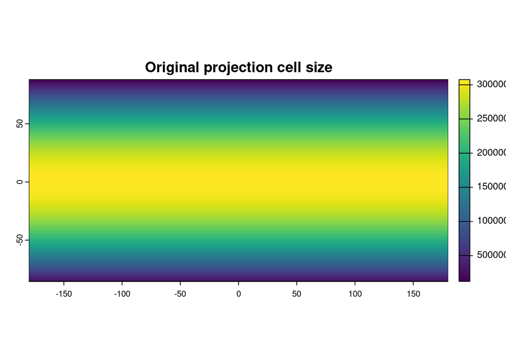

```r
plot(cell_area, main = "Original projection cell size")
```

- 389 million tonnes is crazy

```r
(cell_area_moll$area)
```

```
## class       : SpatRaster
## dimensions  : 764, 1546, 1  (nrow, ncol, nlyr)
## resolution  : 23330.19, 23330.19  (x, y)
## extent      : -18037447, 18031019, -8861637, 8962624  (xmin, xmax, ymin, ymax)
## coord. ref. : +proj=moll +lon_0=0 +x_0=0 +y_0=0 +datum=WGS84 +units=m +no_defs
## source(s)   : memory
## name        :      area
## min value   :         0
## max value   : 547291328
```

```r
# min 0
# max is 547 million
cell_area$area
```

```
## class       : SpatRaster
## dimensions  : 347, 720, 1  (nrow, ncol, nlyr)
## resolution  : 0.5, 0.5  (x, y)
## extent      : -180, 180, -85.5, 88  (xmin, xmax, ymin, ymax)
## coord. ref. : lon/lat WGS 84 (EPSG:4326)
## source(s)   : memory
## varname     : commercial_landings_2017
## name        :       area
## min value   :  122442386
## max value   : 3077249667
```

```r
# min: 122442386 (122 million)
# max: 3077249667 (3 billion)
```

Compare to the original tonnes? What is happening? How can you improve this? - original tons: 86331119 - Mollweide tons: 389271065 - the cell size area is now relatively consistent across the globe – old cell sizes have stretched etc., to fit a standardized cell size (I tried to extend the margins to see the full scalebar label values but struggled) - perform global calculations before reprojecting

- could take raster of cell size, multiply by original (if density) raster, then sum values
- ^ divide if count
- tonnes / area = density, then project
- take new cell size, multiply by density raster
- sum at end to check again – might need to reduce resolution, summary before projecting data

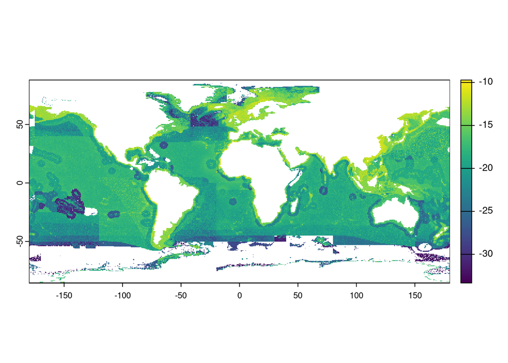

```r
# get density (tonnes/area)
fish_density <- fish / cell_area

plot(log(fish_density))
```

```r
# reproject to Mollweide
fish_density_moll <- terra::project(fish_density, crs(moll))
fish_density_moll
```

```
## class       : SpatRaster
## dimensions  : 764, 1546, 1  (nrow, ncol, nlyr)
## resolution  : 23330.19, 23330.19  (x, y)
## extent      : -18037447, 18031019, -8861637, 8962624  (xmin, xmax, ymin, ymax)
## coord. ref. : +proj=moll +lon_0=0 +x_0=0 +y_0=0 +datum=WGS84 +units=m +no_defs
## source(s)   : memory
## name        : commercial_landings_2017
## min value   :             0.000000e+00
## max value   :             4.908811e-05
```

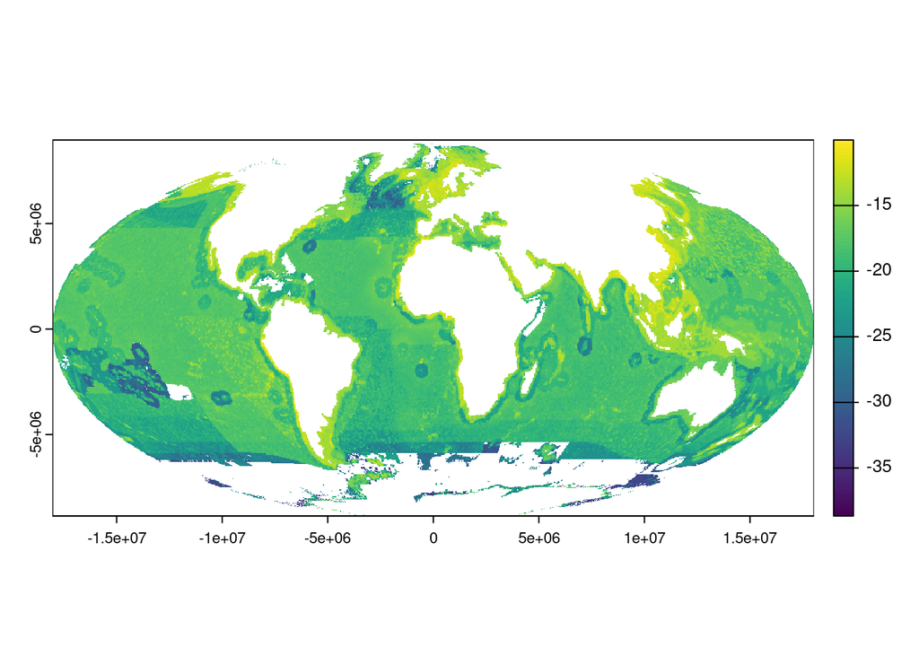

```r
plot(log(fish_density_moll))
```

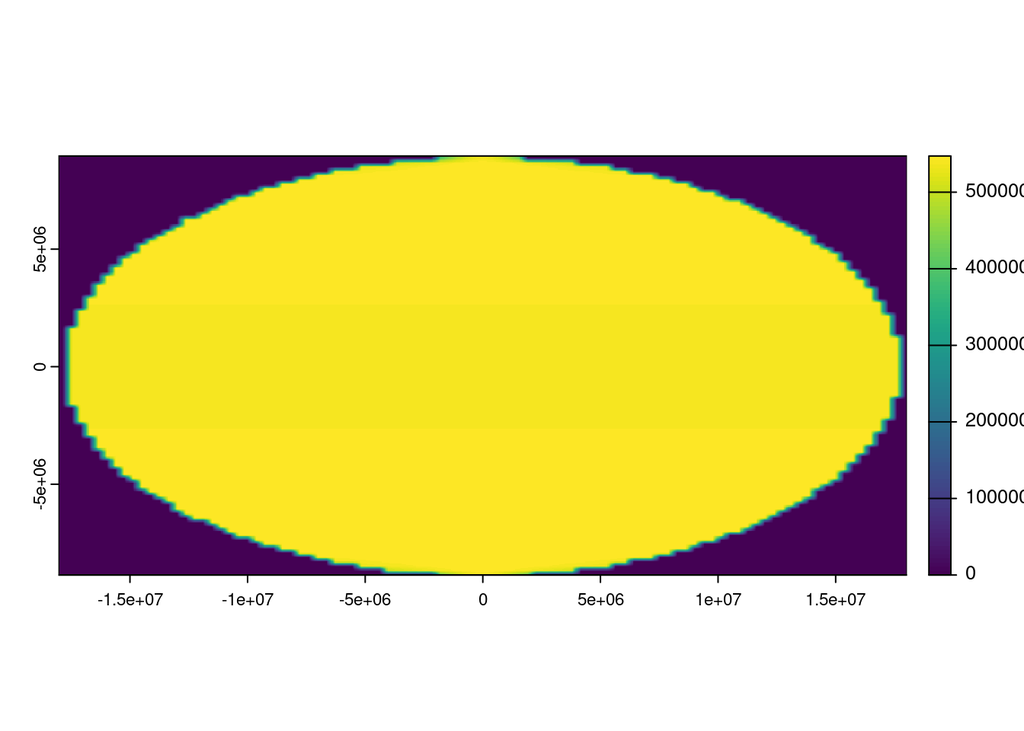

```r
# get area of cells
new_cell_size <- cellSize(fish_density_moll)
plot(new_cell_size)
```

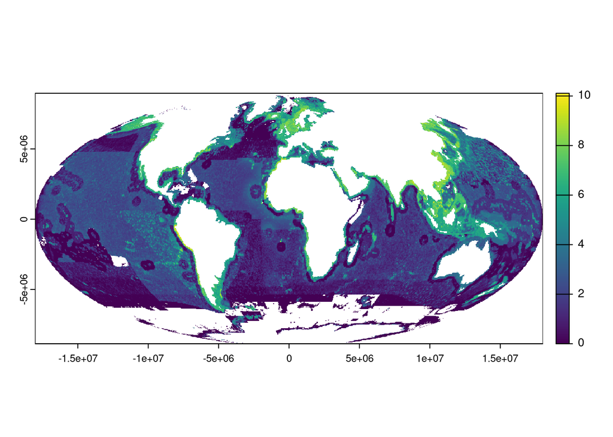

```r
# multiply density by area to get count (tonnes)
new_tonnes <- fish_density_moll * new_cell_size
plot(log(new_tonnes + 1))
```

```r
# sum to check
global(new_tonnes, "sum", na.rm = TRUE)
```

```
##                               sum
## commercial_landings_2017 85253920
```

```r
# 85 million!
```

- close enough :)
- hopefully you don’t care about Fiji data too much (gets distorted with Mollweide projection)

```r
#View(fish)

summary(fish)
```

```
##  commercial_landings_2017
##  Min.   :     0.00
##  1st Qu.:     2.43
##  Median :    22.25
##  Mean   :   651.53
##  3rd Qu.:    84.65
##  Max.   :125112.30
##  NA's   :47150
```

```r
fish_polygons <- terra::as.polygons(fish)

fish_df <- terra::values(fish_polygons)
```

```r
# Get the cell numbers
cells <- 1:terra::ncell(fish)

# Get the x and y coordinates for each cell
xy <- terra::xyFromCell(fish, cells)

# Extract the values
values <- terra::values(fish)

# Combine everything into a data frame
fish_df <- data.frame(
  x = xy[,1],
  y = xy[,2],
  value = values
)

fish_no_na <- fish_df %>%
  na.omit()
```

See what happens when we make multiple CRS conversions:

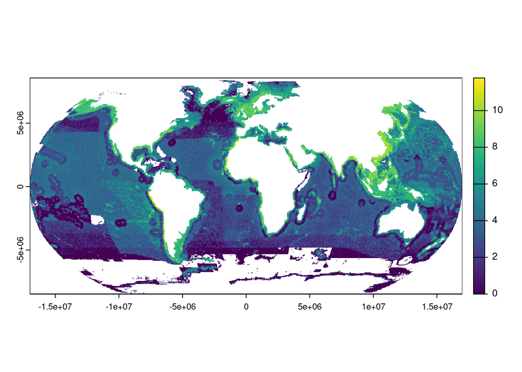

```r
# Robinson projection
rob <- "+proj=robin +datum=WGS84 +units=m +no_defs"

fish_moll_rob <- terra::project(fish_moll, crs(rob))
plot(log(fish_moll_rob + 1))
```

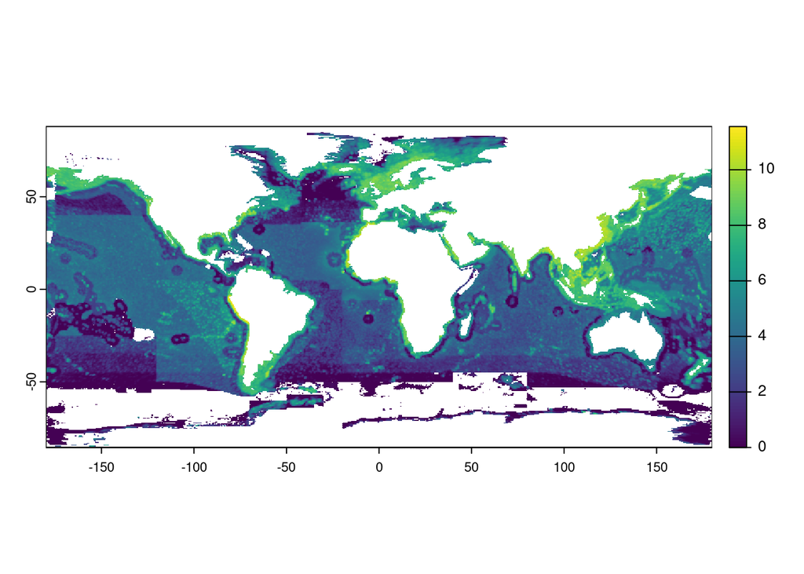

```r
# now back to lat long:
fish_moll_rob_latlon <- project(fish_moll_rob, fish)

plot(log(fish_moll_rob_latlon + 1))
```

```r
plot(log(fish + 1))
```

[output not shown]

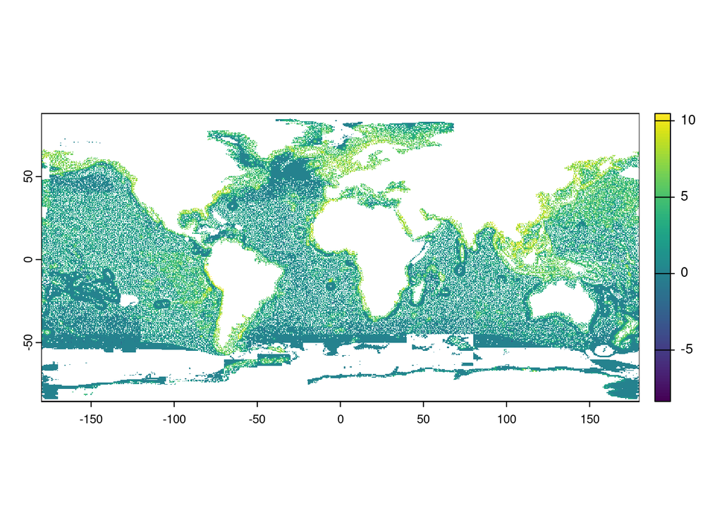

```r
# check to see if it exactly matches the start
check <- fish_moll_rob_latlon - fish
plot(log(check + 1))
```

```r
check
```

```
## class       : SpatRaster
## dimensions  : 347, 720, 1  (nrow, ncol, nlyr)
## resolution  : 0.5, 0.5  (x, y)
## extent      : -180, 180, -85.5, 88  (xmin, xmax, ymin, ymax)
## coord. ref. : lon/lat WGS 84 (EPSG:4326)
## source(s)   : memory
## varname     : commercial_landings_2017
## name        : commercial_landings_2017
## min value   :                -66229.40
## max value   :                 35487.52
```

What is this telling us?

- the values have changed notably between projections
- some are highly inflated (large positive numbers), other deflated (large negative in new projection)
- adding error when we flip between resolutions
- they’re all just approximations (by nature)

```r
fish_moll_rob
```

```
## class       : SpatRaster
## dimensions  : 772, 1542, 1  (nrow, ncol, nlyr)
## resolution  : 22047.33, 22047.33  (x, y)
## extent      : -17003404, 16993576, -8462847, 8557690  (xmin, xmax, ymin, ymax)
## coord. ref. : +proj=robin +lon_0=0 +x_0=0 +y_0=0 +datum=WGS84 +units=m +no_defs
## source(s)   : memory
## name        : commercial_landings_2017
## min value   :                      0.0
## max value   :                 132159.3
```

```r
fish_moll_rob_latlon <- project(fish_moll_rob, fish) # match template (convert crs and resolution)
fish_moll_rob_latlon
```

```
## class       : SpatRaster
## dimensions  : 347, 720, 1  (nrow, ncol, nlyr)
## resolution  : 0.5, 0.5  (x, y)
## extent      : -180, 180, -85.5, 88  (xmin, xmax, ymin, ymax)
## coord. ref. : lon/lat WGS 84 (EPSG:4326)
## source(s)   : memory
## varname     : commercial_landings_2017
## name        : commercial_landings_2017
## min value   :                      0.0
## max value   :                 104592.5
```

```r
fish_moll_rob_latlon_v2 <- project(fish_moll_rob, crs(fish)) # match crs (just convert crs)
fish_moll_rob_latlon_v2
```

```
## class       : SpatRaster
## dimensions  : 750, 1553, 1  (nrow, ncol, nlyr)
## resolution  : 0.2316815, 0.2318308  (x, y)
## extent      : -180, 179.8014, -85.87307, 88  (xmin, xmax, ymin, ymax)
## coord. ref. : lon/lat WGS 84 (EPSG:4326)
## source(s)   : memory
## name        : commercial_landings_2017
## min value   :                      0.0
## max value   :                 127646.3
```